# Work Absenteeism

### Variable Mutation and Normalization

```
Observations: 740
Variables: 29
$ PK                         <int> 4, 8, 11, 12, 13, 16, 24, 28, 38, 40, 41...
$ Education                  <ord> High_school, High_school, High_school, H...
$ Reason                     <fct> 7, 23, 1, 1, 11, 14, 28, 28, 11, 23, 23,...
$ Day_of_week                <fct> Thursday, Friday, Monday, Tuesday, Wedne...
$ Seasons                    <fct> Summer, Summer, Summer, Summer, Summer, ...
$ Transportation_expense     <int> 279, 260, 260, 260, 260, 246, 260, 157, ...
$ Service_time               <int> 14, 11, 11, 11, 11, 16, 11, 6, 12, 11, 7...
$ Commute_distance           <int> 5, 50, 50, 50, 50, 25, 50, 27, 50, 50, 4...
$ Age                        <int> 39, 36, 36, 36, 36, 41, 36, 29, 32, 36, ...
$ Hit_target                 <int> 97, 97, 97, 97, 97, 97, 92, 92, 92, 92, ...
$ Disciplinary_failure       <lgl> FALSE, FALSE, FALSE, FALSE, FALSE, FALSE...
$ Num_children               <int> 2, 4, 4, 4, 4, 0, 4, 0, 0, 4, 0, 4, 4, 1...
$ Num_pets                   <int> 0, 0, 0, 0, 0, 0, 0, 0, 0, 0, 0, 0, 0, 2...
```

[output cut: 16 more lines]

```
       PK                Education       Reason       Day_of_week    Seasons
 Min.   :  1.0   High_school  :611   23     :149   Monday   :161   Summer:170
 1st Qu.:185.8   Undergraduate: 46   28     :112   Tuesday  :154   Autumn:192
 Median :370.5   Graduate     : 79   27     : 69   Wednesday:156   Winter:183
 Mean   :370.5   Doctorate    :  4   13     : 55   Thursday :125   Spring:195
 3rd Qu.:555.2                       0      : 43   Friday   :144
 Max.   :740.0                       19     : 40
                                     (Other):272
 Transportation_expense  Service_time   Commute_distance      Age
 Min.   :118.0          Min.   : 1.00   Min.   : 5.00    Min.   :27.00
 1st Qu.:179.0          1st Qu.: 9.00   1st Qu.:16.00    1st Qu.:31.00
 Median :225.0          Median :13.00   Median :26.00    Median :37.00
 Mean   :221.3          Mean   :12.55   Mean   :29.63    Mean   :36.45
 3rd Qu.:260.0          3rd Qu.:16.00   3rd Qu.:50.00    3rd Qu.:40.00
 Max.   :388.0          Max.   :29.00   Max.   :52.00    Max.   :58.00

   Hit_target     Disciplinary_failure  Num_children      Num_pets
 Min.   : 81.00   Mode :logical        Min.   :0.000   Min.   :0.0000
 1st Qu.: 93.00   FALSE:700            1st Qu.:0.000   1st Qu.:0.0000
 Median : 95.00   TRUE :40             Median :1.000   Median :0.0000
 Mean   : 94.59                        Mean   :1.019   Mean   :0.7459
 3rd Qu.: 97.00                        3rd Qu.:2.000   3rd Qu.:1.0000
 Max.   :100.00                        Max.   :4.000   Max.   :8.0000

 Social_drinker  Social_smoker   Absenteeism_hours      BMI_status
 Mode :logical   Mode :logical   Min.   :  0.000   normal    :264
 FALSE:320       FALSE:686       1st Qu.:  2.000   overweight:232
 TRUE :420       TRUE :54        Median :  3.000   obese     :244
                                 Mean   :  6.924
                                 3rd Qu.:  8.000
                                 Max.   :120.000

 Absenteeism_hours.log Absenteeism_hours.sqr    Age.log         Age.sqr
 Min.   :  -Inf        Min.   : 0.000        Min.   :3.296   Min.   :5.196
 1st Qu.:0.6931        1st Qu.: 1.414        1st Qu.:3.434   1st Qu.:5.568
 Median :1.0986        Median : 1.732        Median :3.611   Median :6.083
 Mean   :  -Inf        Mean   : 2.162        Mean   :3.581   Mean   :6.014
 3rd Qu.:2.0794        3rd Qu.: 2.828        3rd Qu.:3.689   3rd Qu.:6.325
 Max.   :4.7875        Max.   :10.954        Max.   :4.060   Max.   :7.616

```

[output cut: 8 more lines]

```
  Num_pets.log    Num_pets.sqr    Transportation_expense.log
 Min.   : -Inf   Min.   :0.0000   Min.   :4.771
 1st Qu.: -Inf   1st Qu.:0.0000   1st Qu.:5.187
 Median : -Inf   Median :0.0000   Median :5.416
 Mean   : -Inf   Mean   :0.5051   Mean   :5.352
 3rd Qu.:0.000   3rd Qu.:1.0000   3rd Qu.:5.561
 Max.   :2.079   Max.   :2.8284   Max.   :5.961

 Transportation_expense.sqr
 Min.   :10.86
 1st Qu.:13.38
 Median :15.00
 Mean   :14.71
 3rd Qu.:16.12
 Max.   :19.70
```

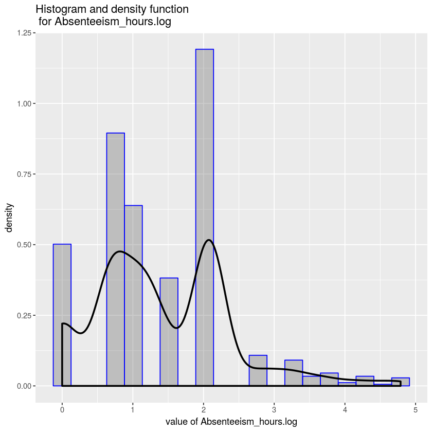

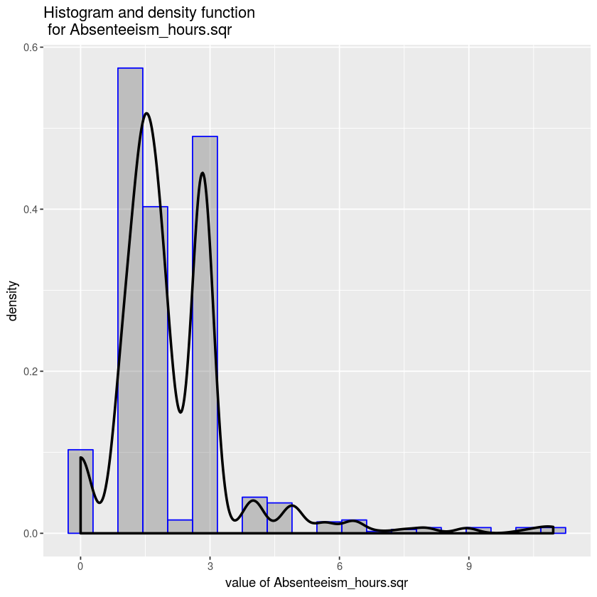

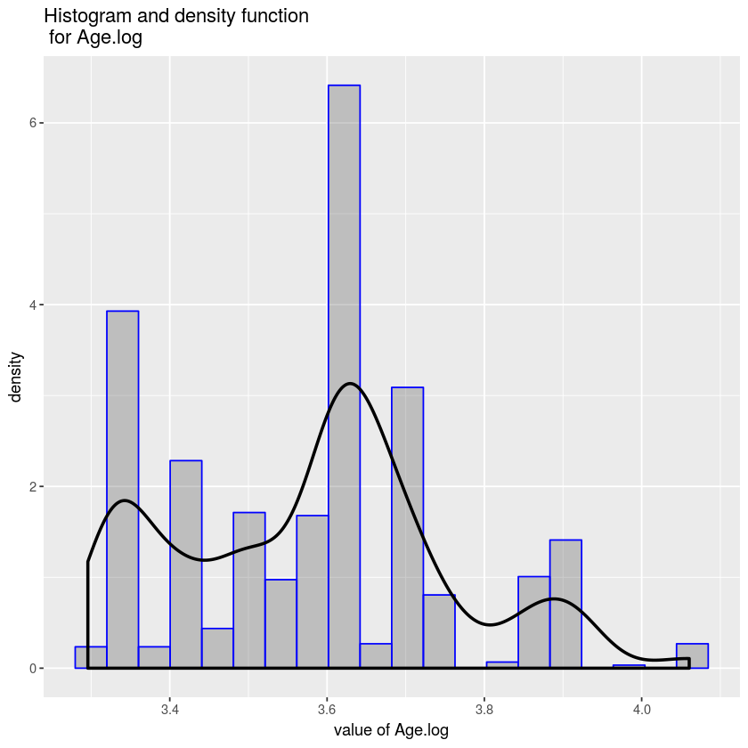

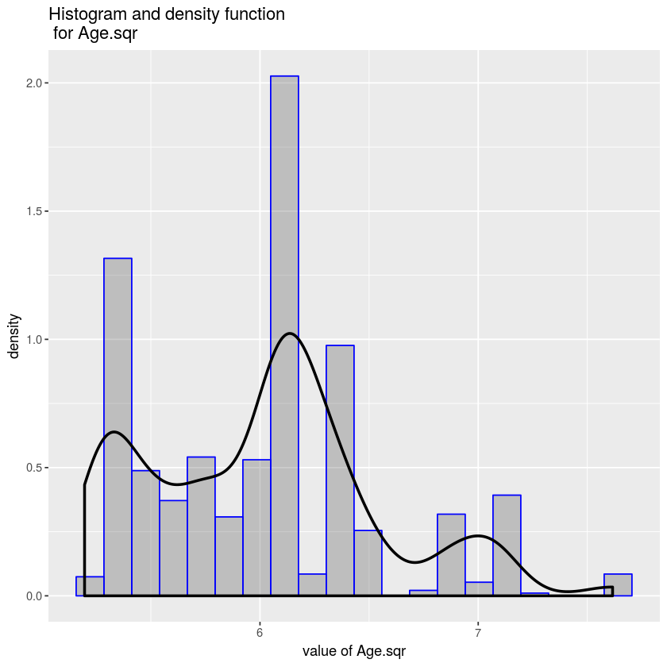

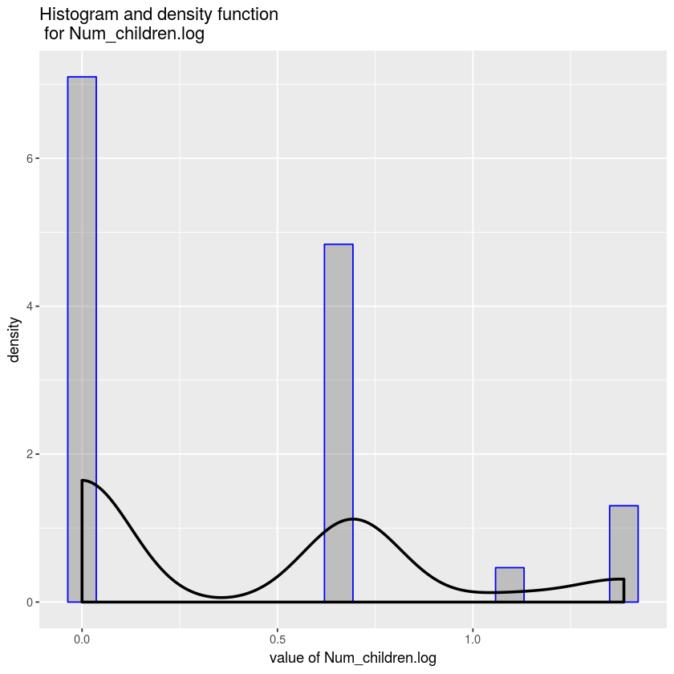

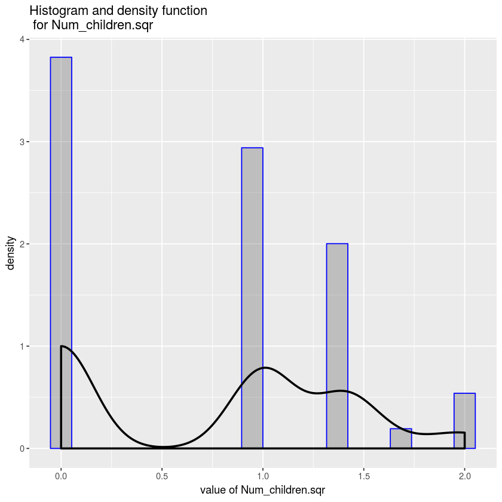

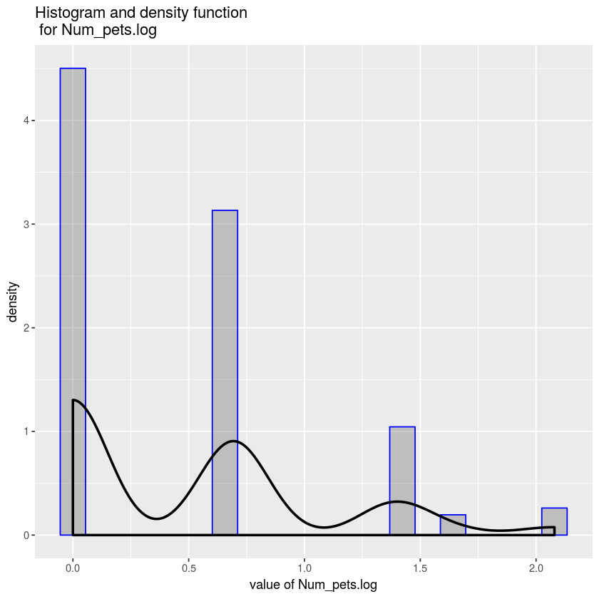

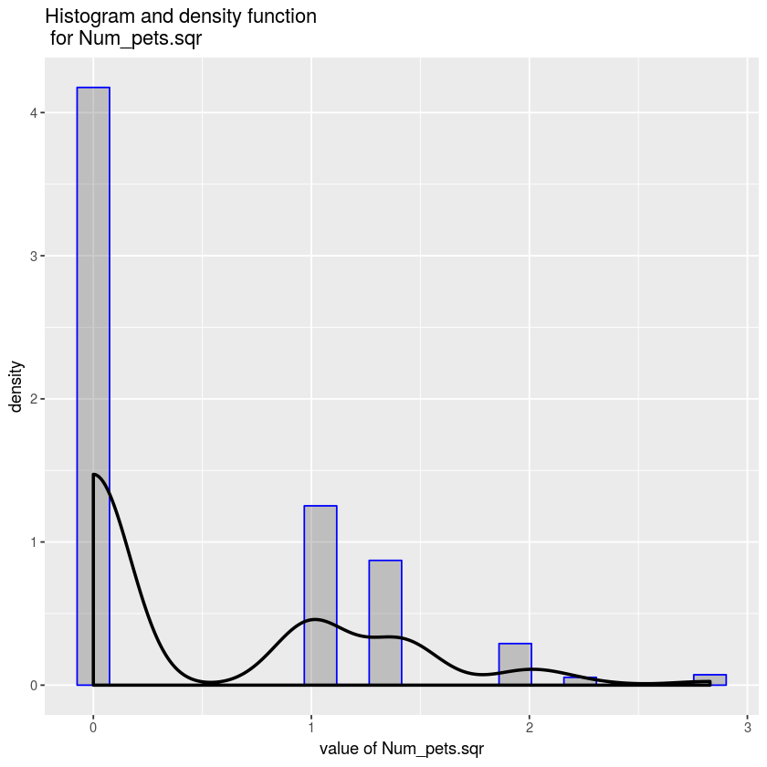

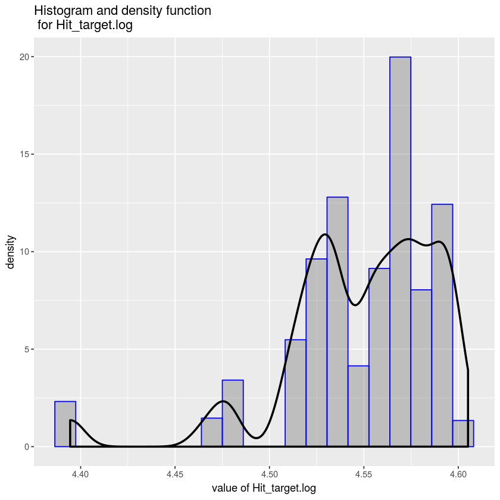

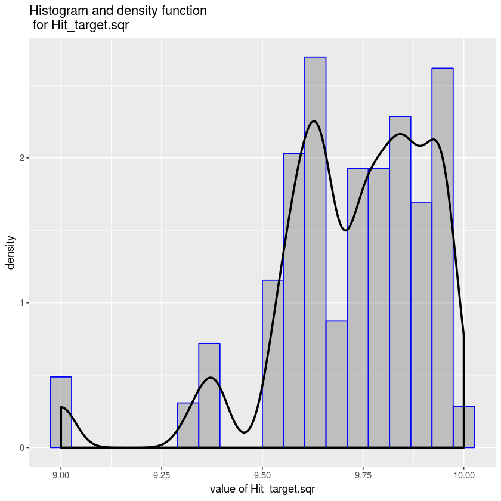

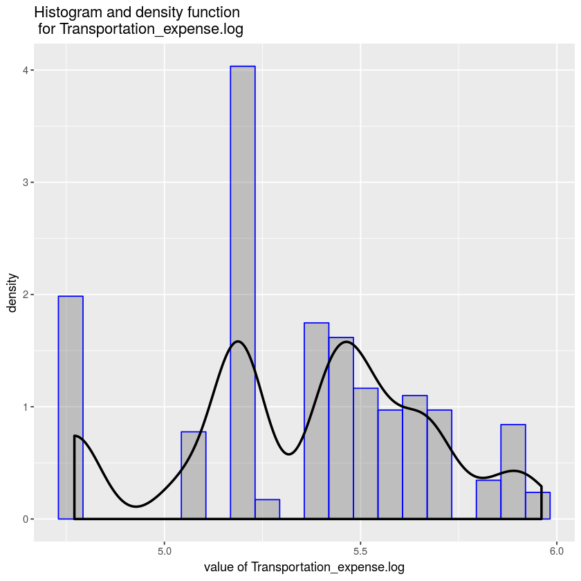

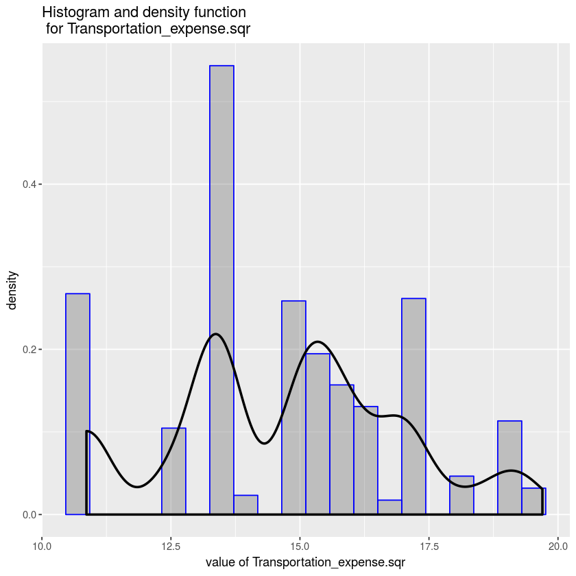

```r
#Update the existing data frame
 df_mutate <- df%>%
   mutate(Absenteeism_hours.log = log(Absenteeism_hours),
         Absenteeism_hours.sqr = sqrt(Absenteeism_hours),
         Age.log=log(Age),
         Age.sqr=sqrt(Age),
         Hit_target.log=log(Hit_target),
         Hit_target.sqr=sqrt(Hit_target),
         Num_children.log=log(Num_children),
         Num_children.sqr=sqrt(Num_children),
         Num_pets.log=log(Num_pets),
         Num_pets.sqr=sqrt(Num_pets),
         Transportation_expense.log=log(Transportation_expense),
         Transportation_expense.sqr=sqrt(Transportation_expense))

df_mutate %>% glimpse() %>% summary()

cols <- c("Absenteeism_hours.log", "Absenteeism_hours.sqr", "Age.log", "Age.sqr", "Num_children.log", "Num_children.sqr",
          "Num_pets.log", "Num_pets.sqr", "Hit_target.log","Hit_target.sqr", "Transportation_expense.log",
          "Transportation_expense.sqr")

cols %>% walk(plot.hists, df=df_mutate)
```

Compared with the above groups of charts, Absenteeism_hours.sqr is more symmetric than Absenteeism_hours, so we will use Absenteeism_hours.sqr as our label. Others variables do not have significant changes after mutatation so we will try modeling with the different variations.

```r
# normalize function
normalize <- function(x) (x - mean(x))/sd(x)

# normalized dataframe
df_mutate_norm <- df_mutate %>%
  mutate(Age = normalize(Age),
         Age.log = normalize(Age.log),
         Num_children = normalize(Num_children),
         Num_pets = normalize(Num_pets),
         Num_pets.sqr = normalize(Num_pets.sqr),
         Hit_target = normalize(Hit_target),
         Hit_target.log = normalize(Hit_target.log),
         Hit_target.sqr = normalize(Hit_target.sqr),
         Commute_distance = normalize(Commute_distance),
         Transportation_expense=normalize(Transportation_expense),
         Transportation_expense.log = normalize(Transportation_expense.log),
         Transportation_expense.sqr = normalize(Transportation_expense.sqr),
         Service_time=normalize(Service_time)) %>%
    select(-PK, -Age.sqr, -Num_pets.log, -Num_children.log, -Num_children.sqr, -Absenteeism_hours.log)

df_mutate_norm %>% glimpse()
```

```
Observations: 740
Variables: 23
$ Education                  <ord> High_school, High_school, High_school, H...
$ Reason                     <fct> 7, 23, 1, 1, 11, 14, 28, 28, 11, 23, 23,...
$ Day_of_week                <fct> Thursday, Friday, Monday, Tuesday, Wedne...
$ Seasons                    <fct> Summer, Summer, Summer, Summer, Summer, ...
$ Transportation_expense     <dbl> 0.86136453, 0.57758008, 0.57758008, 0.57...
$ Service_time               <dbl> 0.3297577, -0.3544125, -0.3544125, -0.35...
$ Commute_distance           <dbl> -1.6601356, 1.3728658, 1.3728658, 1.3728...
$ Age                        <dbl> 0.3935931, -0.0694576, -0.0694576, -0.06...
$ Hit_target                 <dbl> 0.6382541, 0.6382541, 0.6382541, 0.63825...
$ Disciplinary_failure       <lgl> FALSE, FALSE, FALSE, FALSE, FALSE, FALSE...
$ Num_children               <dbl> 0.89311870, 2.71380144, 2.71380144, 2.71...
$ Num_pets                   <dbl> -0.5658572, -0.5658572, -0.5658572, -0.5...
$ Social_drinker             <lgl> TRUE, TRUE, TRUE, TRUE, TRUE, TRUE, TRUE...
$ Social_smoker              <lgl> TRUE, FALSE, FALSE, FALSE, FALSE, FALSE,...
$ Absenteeism_hours          <int> 4, 4, 8, 8, 8, 8, 4, 4, 4, 4, 2, 8, 0, 0...
$ BMI_status                 <ord> normal, normal, normal, normal, normal, ...
$ Absenteeism_hours.sqr      <dbl> 2.000000, 2.000000, 2.828427, 2.828427, ...
$ Age.log                    <dbl> 0.47823017, 0.01589293, 0.01589293, 0.01...
$ Hit_target.log             <dbl> 0.6326562, 0.6326562, 0.6326562, 0.63265...
$ Hit_target.sqr             <dbl> 0.6356619, 0.6356619, 0.6356619, 0.63566...
$ Num_pets.sqr               <dbl> -0.7205817, -0.7205817, -0.7205817, -0.7...
$ Transportation_expense.log <dbl> 0.8913514, 0.6659129, 0.6659129, 0.66591...
$ Transportation_expense.sqr <dbl> 0.8854488, 0.6289573, 0.6289573, 0.62895...
```

# Split the training and testing set

```r
set.seed(2345)

df_train <- df_mutate_norm %>% sample_frac(0.8)

df_test <- df_mutate_norm %>% setdiff(df_train)

df_train %>% glimpse()
df_test %>% glimpse()
```

```
Observations: 592
Variables: 23
$ Education                  <ord> High_school, High_school, High_school, U...
$ Reason                     <fct> 19, 0, 23, 21, 28, 7, 18, 23, 27, 0, 1, ...
$ Day_of_week                <fct> Wednesday, Thursday, Wednesday, Thursday...
$ Seasons                    <fct> Winter, Winter, Spring, Spring, Summer, ...
$ Transportation_expense     <dbl> 2.34003089, 0.36847574, -0.63223785, -0....
$ Service_time               <dbl> -0.3544125, 0.7858713, 1.2419848, 1.0139...
$ Commute_distance           <dbl> 1.30546573, -0.31213501, 1.44026580, -0....
$ Age                        <dbl> -0.06945760, 0.70229353, 0.23924285, 0.5...
$ Hit_target                 <dbl> 0.3736558, 0.9028525, -0.6847376, -0.420...
$ Disciplinary_failure       <lgl> FALSE, TRUE, FALSE, FALSE, FALSE, FALSE,...
$ Num_children               <dbl> 0.89311870, -0.92756405, -0.92756405, 0....
$ Num_pets                   <dbl> 2.4684495, -0.5658572, -0.5658572, -0.56...
$ Social_drinker             <lgl> FALSE, TRUE, TRUE, FALSE, TRUE, FALSE, T...
```

[output cut: 35 more lines]

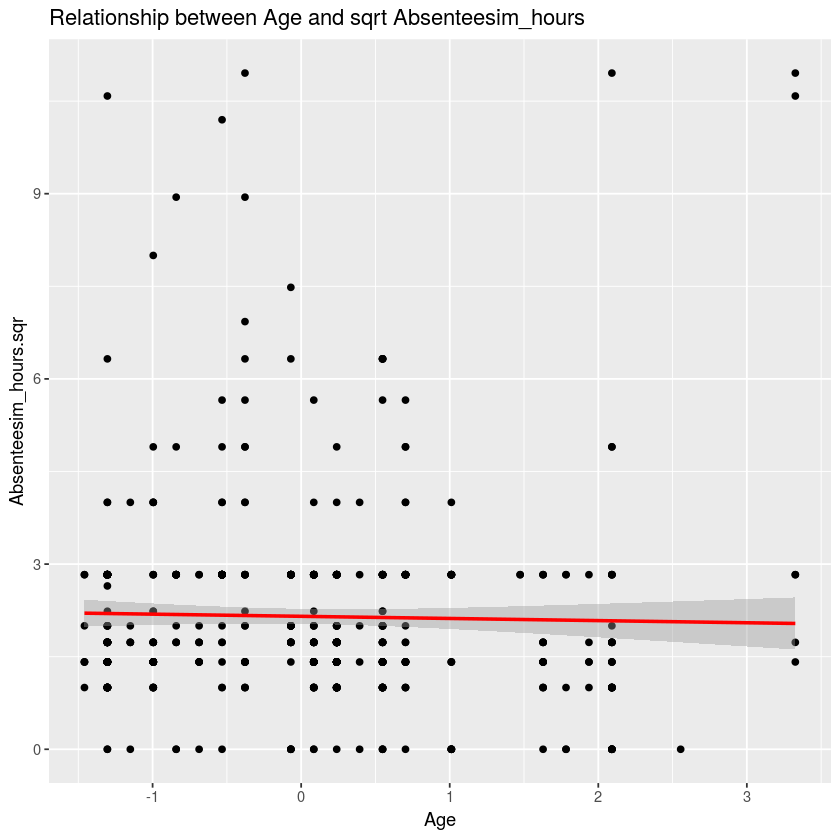

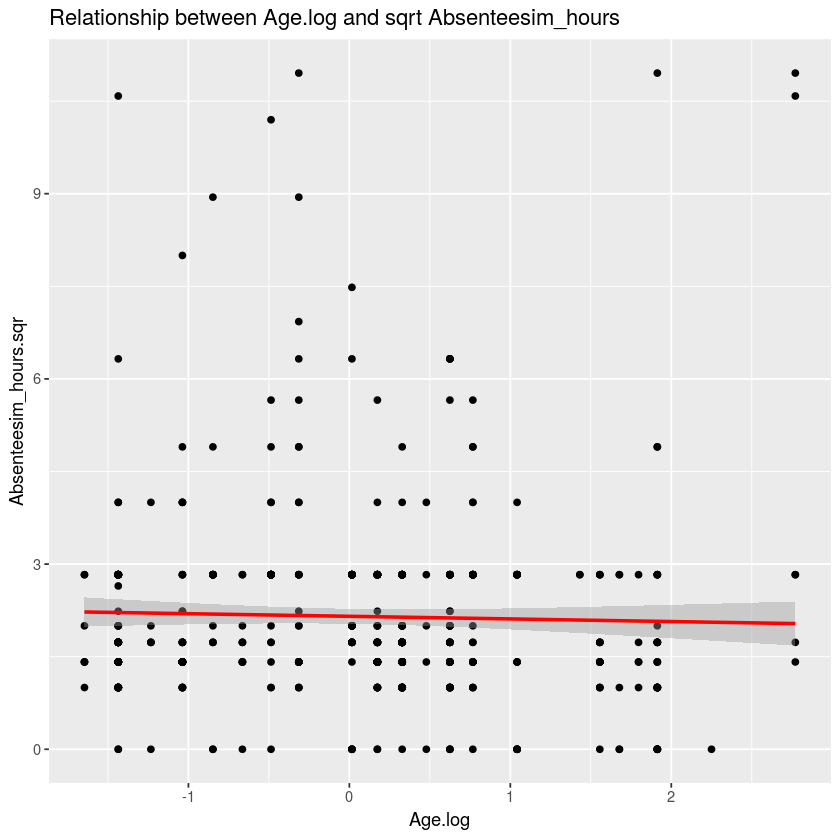

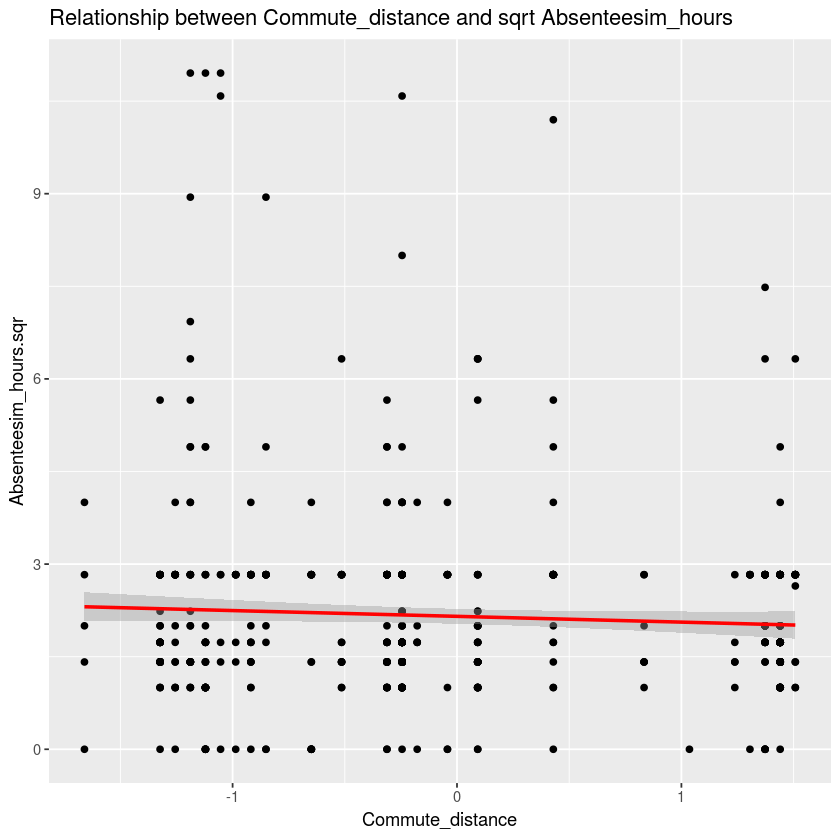

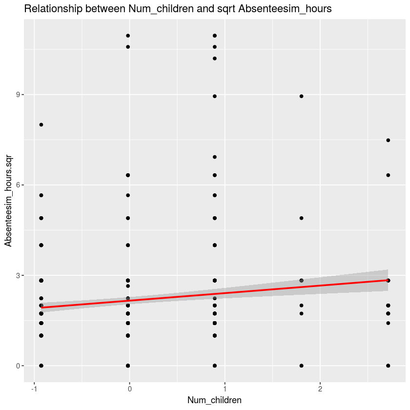

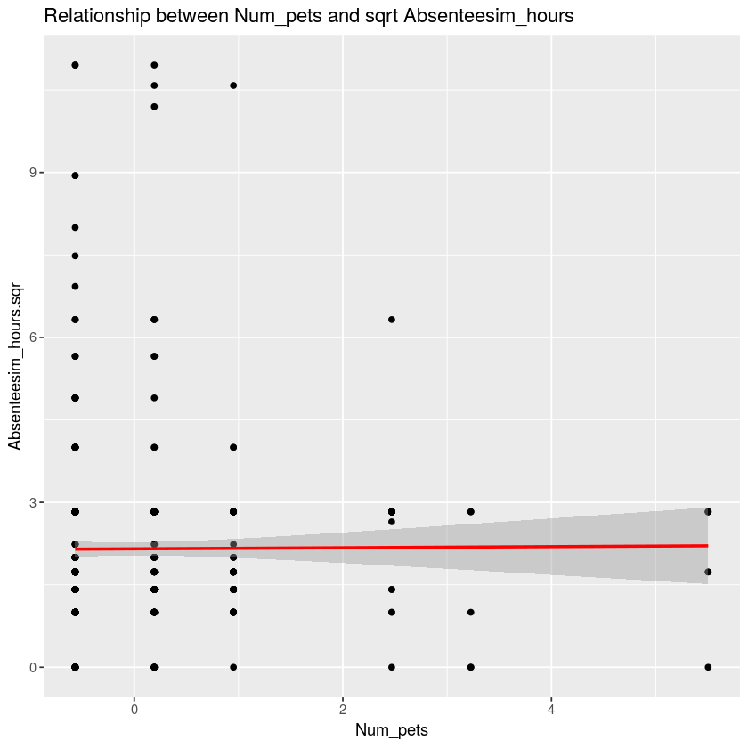

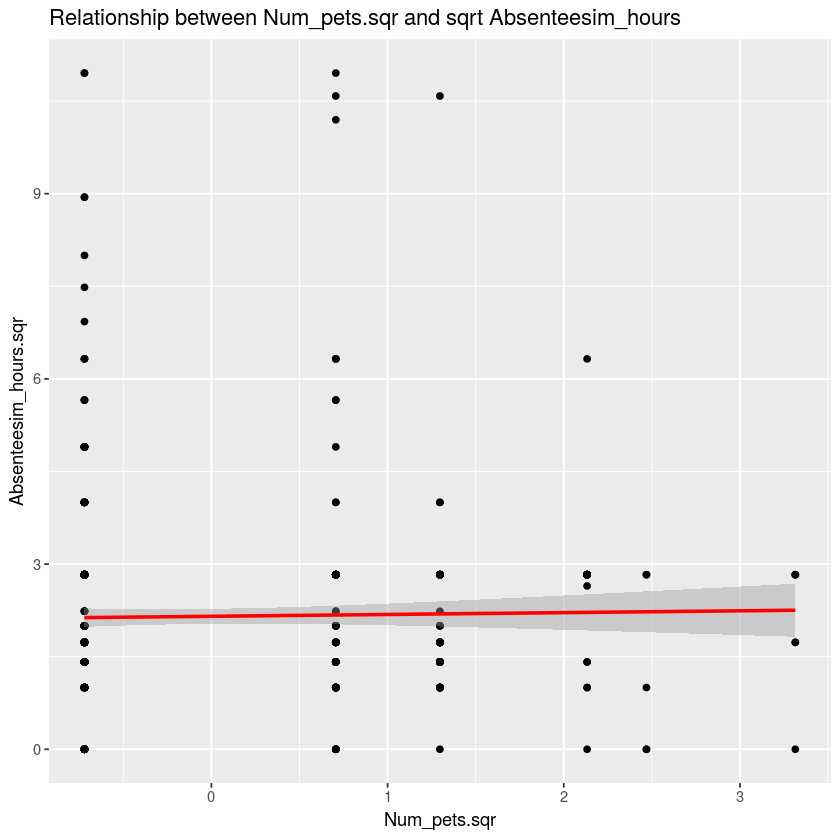

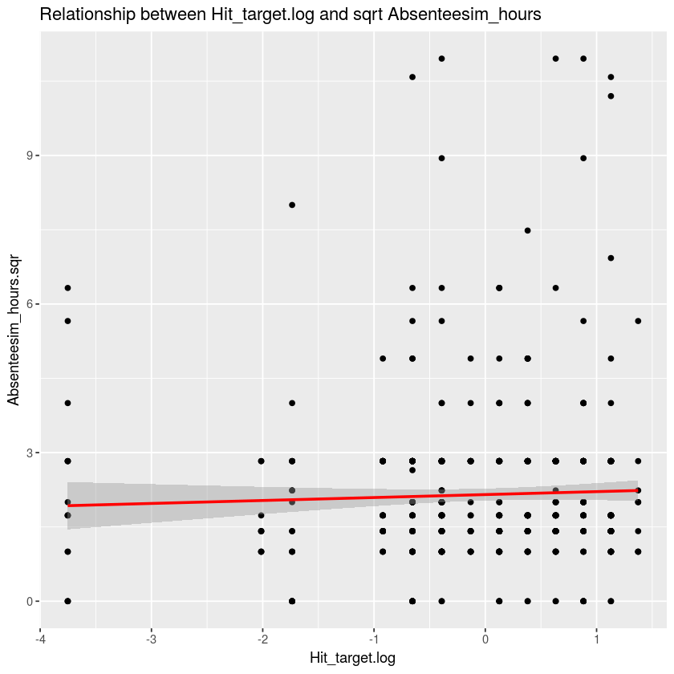

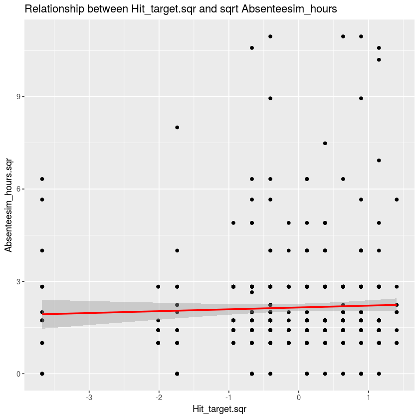

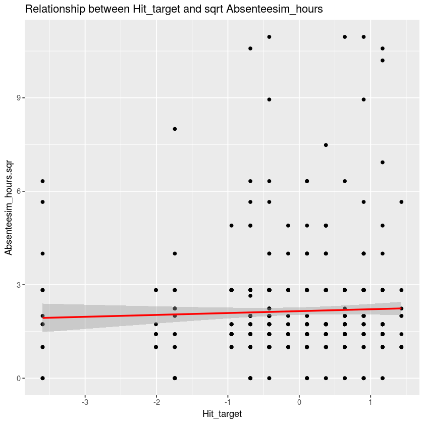

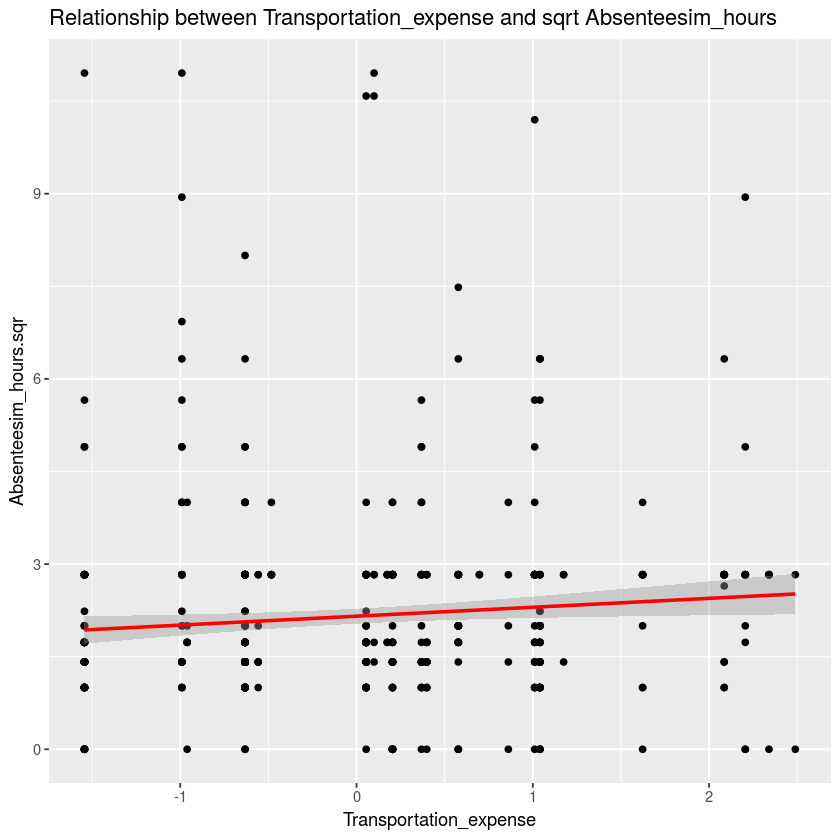

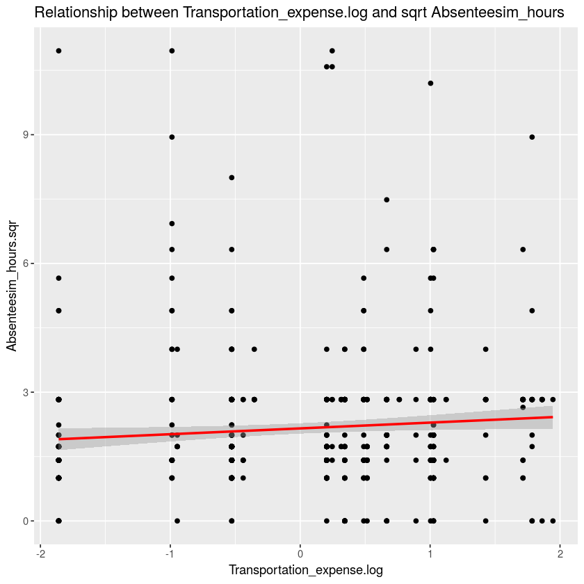

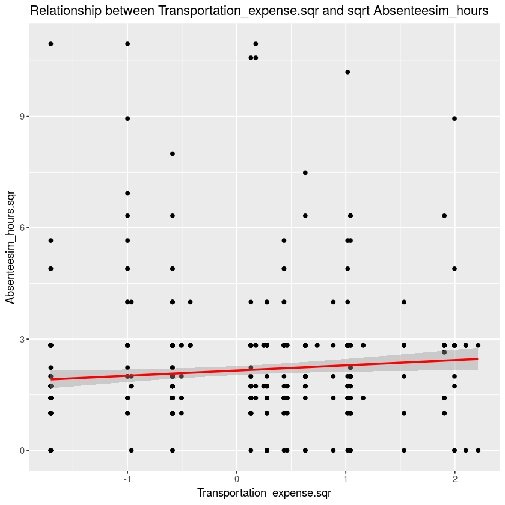

[1 more figures not shown]

```r
#plot features
plot.feature = function(col, df){
  p1 = ggplot(df, aes_string(x = col, y = 'Absenteeism_hours.sqr')) +
    geom_point() +
    geom_smooth(size = 1, color = 'red', method="lm") +
    labs(title=str_c("Relationship between ", col, " and sqrt Absenteesim_hours"),
         x=col, y="Absenteesim_hours.sqr")

  p1 %>% print()
}

cols = c('Age', 'Age.log', 'Commute_distance','Num_children','Num_pets', 'Num_pets.sqr', "Hit_target.log","Hit_target.sqr",
         'Hit_target', 'Transportation_expense', 'Transportation_expense.log', 'Transportation_expense.sqr', 'Service_time')

cols %>% walk(plot.feature, df_train)
```

# Train the model with training set

## Model 1

```r
model_1<- lm(Absenteeism_hours.sqr ~ Commute_distance+Num_children+Transportation_expense+Transportation_expense.log+
             Transportation_expense.sqr, data=df_train)
model_1%>%summary
```

```
Call:
lm(formula = Absenteeism_hours.sqr ~ Commute_distance + Num_children +
    Transportation_expense + Transportation_expense.log + Transportation_expense.sqr,
    data = df_train)

Residuals:
    Min      1Q  Median      3Q     Max
-3.1933 -0.7614 -0.3385  0.5429  8.9331

Coefficients:
                            Estimate Std. Error t value Pr(>|t|)
(Intercept)                  2.15833    0.06107  35.341  < 2e-16 ***
Commute_distance            -0.16740    0.07055  -2.373  0.01798 *
Num_children                 0.23603    0.06774   3.485  0.00053 ***
Transportation_expense      14.69546    6.71927   2.187  0.02913 *
Transportation_expense.log  14.54706    6.71939   2.165  0.03080 *
Transportation_expense.sqr -29.01346   13.35915  -2.172  0.03027 *
---
Signif. codes:  0 ‘***’ 0.001 ‘**’ 0.01 ‘*’ 0.05 ‘.’ 0.1 ‘ ’ 1

Residual standard error: 1.485 on 586 degrees of freedom
Multiple R-squared:  0.04149,	Adjusted R-squared:  0.03331
F-statistic: 5.073 on 5 and 586 DF,  p-value: 0.0001459
```

## Model 2

```r
model_2<- lm(Absenteeism_hours.sqr ~ Num_children, data=df_train)
model_2%>%summary
```

```
Call:
lm(formula = Absenteeism_hours.sqr ~ Num_children, data = df_train)

Residuals:
    Min      1Q  Median      3Q     Max
-2.8379 -0.7412 -0.1958  0.6731  8.7991

Coefficients:
             Estimate Std. Error t value Pr(>|t|)
(Intercept)   2.15968    0.06133  35.216  < 2e-16 ***
Num_children  0.24990    0.06225   4.015 6.72e-05 ***
---
Signif. codes:  0 ‘***’ 0.001 ‘**’ 0.01 ‘*’ 0.05 ‘.’ 0.1 ‘ ’ 1

Residual standard error: 1.492 on 590 degrees of freedom
Multiple R-squared:  0.02659,	Adjusted R-squared:  0.02494
F-statistic: 16.12 on 1 and 590 DF,  p-value: 6.72e-05
```

# Model Performance Comparison

| Absenteeism_hours | score | resids | predicted.Absenteeism |
| --- | --- | --- | --- |
| 4 | 2.495714 | -0.49571419 | 6.228589 |
| 4 | 2.495714 | -0.49571419 | 6.228589 |
| 1 | 2.070591 | -1.07059101 | 4.287347 |
| 16 | 2.495714 | 1.50428581 | 6.228589 |
| 1 | 2.175632 | -1.17563165 | 4.733373 |
| 3 | 2.175632 | -0.44358084 | 4.733373 |
| 2 | 2.175632 | -0.76141808 | 4.733373 |
| 8 | 2.797205 | 0.03122225 | 7.824355 |
| 2 | 2.175632 | -0.76141808 | 4.733373 |
| 2 | 2.175632 | -0.76141808 | 4.733373 |
| 8 | 2.495714 | 0.33271294 | 6.228589 |
| 16 | 2.495714 | 1.50428581 | 6.228589 |
| 8 | 2.545464 | 0.28296338 | 6.479386 |
| 4 | 2.495714 | -0.49571419 | 6.228589 |
| 2 | 2.175632 | -0.76141808 | 4.733373 |
| 4 | 2.495714 | -0.49571419 | 6.228589 |
| 0 | 2.581805 | -2.58180491 | 6.665717 |
| 0 | 2.719352 | -2.71935244 | 7.394878 |
| 8 | 1.930790 | 0.89763724 | 3.727950 |
| 8 | 2.070591 | 0.75783612 | 4.287347 |
| 4 | 2.495714 | -0.49571419 | 6.228589 |
| 4 | 2.495714 | -0.49571419 | 6.228589 |
| 8 | 2.070591 | 0.75783612 | 4.287347 |
| 3 | 2.495714 | -0.76366338 | 6.228589 |
| 0 | 2.719352 | -2.71935244 | 7.394878 |
| 2 | 2.050544 | -0.63633049 | 4.204731 |
| 24 | 1.930790 | 2.96818960 | 3.727950 |
| 8 | 2.545464 | 0.28296338 | 6.479386 |
| 2 | 2.545464 | -1.13125018 | 6.479386 |
| 3 | 2.175632 | -0.44358084 | 4.733373 |
| ⋮ | ⋮ | ⋮ | ⋮ |
| 8 | 2.220905 | 0.6075217 | 4.932421 |
| 8 | 2.249408 | 0.5790188 | 5.059838 |
| 16 | 2.249408 | 1.7505916 | 5.059838 |
| 1 | 2.021375 | -1.0213750 | 4.085957 |
| 2 | 2.357901 | -0.9436874 | 5.559697 |
| 1 | 1.788520 | -0.7885199 | 3.198803 |
| 8 | 2.249408 | 0.5790188 | 5.059838 |
| 8 | 2.220905 | 0.6075217 | 4.932421 |
| 2 | 2.021375 | -0.6071615 | 4.085957 |
| 8 | 2.249408 | 0.5790188 | 5.059838 |
| 4 | 2.357901 | -0.3579009 | 5.559697 |
| 4 | 1.788520 | 0.2114801 | 3.198803 |
| 4 | 1.788520 | 0.2114801 | 3.198803 |
| 1 | 2.357901 | -1.3579009 | 5.559697 |
| 4 | 1.788520 | 0.2114801 | 3.198803 |
| 1 | 1.788520 | -0.7885199 | 3.198803 |
| 0 | 2.249408 | -2.2494084 | 5.059838 |
| 4 | 2.357901 | -0.3579009 | 5.559697 |
| 32 | 1.788520 | 3.8683343 | 3.198803 |
| 8 | 2.220905 | 0.6075217 | 4.932421 |
| 8 | 1.788520 | 1.0399072 | 3.198803 |
| 8 | 2.357901 | 0.4705262 | 5.559697 |
| 3 | 1.788520 | -0.0564691 | 3.198803 |
| 8 | 1.788520 | 1.0399072 | 3.198803 |
| 4 | 1.788520 | 0.2114801 | 3.198803 |
| 2 | 2.357901 | -0.9436874 | 5.559697 |
| 8 | 2.249408 | 0.5790188 | 5.059838 |
| 3 | 1.788520 | -0.0564691 | 3.198803 |
| 4 | 2.220905 | -0.2209054 | 4.932421 |
| 0 | 2.274986 | -2.2749864 | 5.175563 |

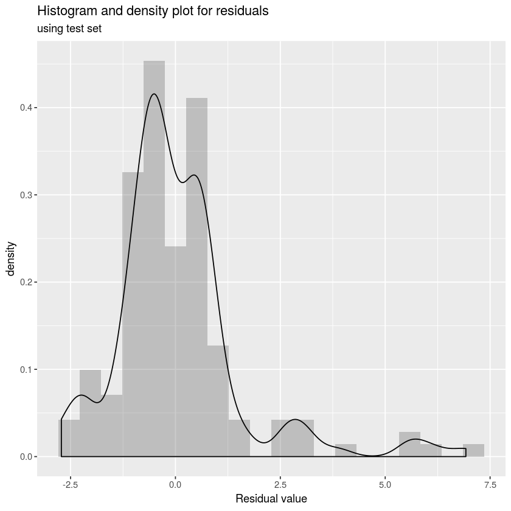

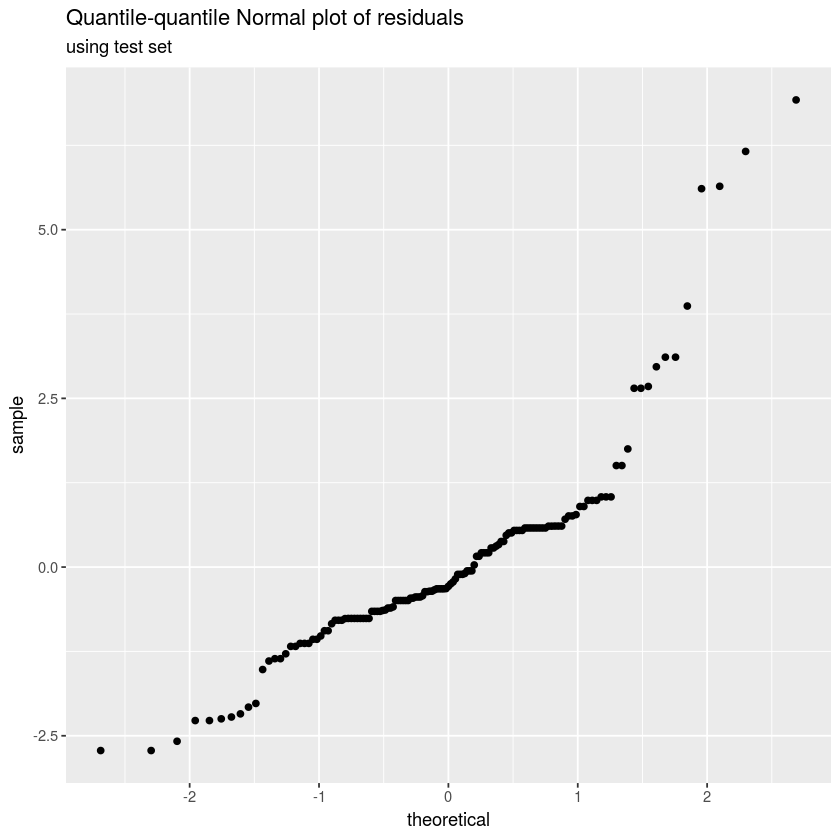

**(Intercept)**

2.15833280252135

**Commute_distance**

-0.167401167447428

**Num_children**

0.236033081245694

**Transportation_expense**

14.6954602641567

**Transportation_expense.log**

14.5470596930762

**Transportation_expense.sqr**

-29.0134593861387

| Absenteeism_hours | score | resids | predicted.Absenteeism |
| --- | --- | --- | --- |
| 4 | 2.837862 | -0.837862322 | 8.053463 |
| 4 | 2.837862 | -0.837862322 | 8.053463 |
| 1 | 1.927877 | -0.927877193 | 3.716710 |
| 16 | 2.837862 | 1.162137678 | 8.053463 |
| 1 | 2.155373 | -1.155373475 | 4.645635 |
| 3 | 2.155373 | -0.423322667 | 4.645635 |
| 2 | 2.155373 | -0.741159913 | 4.645635 |
| 8 | 1.927877 | 0.900549932 | 3.716710 |
| 2 | 2.155373 | -0.741159913 | 4.645635 |
| 2 | 2.155373 | -0.741159913 | 4.645635 |
| 8 | 2.837862 | -0.009435197 | 8.053463 |
| 16 | 2.837862 | 1.162137678 | 8.053463 |
| 8 | 2.382870 | 0.445557367 | 5.678068 |
| 4 | 2.837862 | -0.837862322 | 8.053463 |
| 2 | 2.155373 | -0.741159913 | 4.645635 |
| 4 | 2.837862 | -0.837862322 | 8.053463 |
| 0 | 2.382870 | -2.382869757 | 5.678068 |
| 0 | 2.382870 | -2.382869757 | 5.678068 |
| 8 | 1.927877 | 0.900549932 | 3.716710 |
| 8 | 1.927877 | 0.900549932 | 3.716710 |
| 4 | 2.837862 | -0.837862322 | 8.053463 |
| 4 | 2.837862 | -0.837862322 | 8.053463 |
| 8 | 1.927877 | 0.900549932 | 3.716710 |
| 3 | 2.837862 | -1.105811515 | 8.053463 |
| 0 | 2.382870 | -2.382869757 | 5.678068 |
| 2 | 1.927877 | -0.513663630 | 3.716710 |
| 24 | 1.927877 | 2.971102293 | 3.716710 |
| 8 | 2.382870 | 0.445557367 | 5.678068 |
| 2 | 2.382870 | -0.968656195 | 5.678068 |
| 3 | 2.155373 | -0.423322667 | 4.645635 |
| ⋮ | ⋮ | ⋮ | ⋮ |
| 8 | 2.155373 | 0.67305365 | 4.645635 |
| 8 | 2.382870 | 0.44555737 | 5.678068 |
| 16 | 2.382870 | 1.61713024 | 5.678068 |
| 1 | 2.155373 | -1.15537347 | 4.645635 |
| 2 | 2.382870 | -0.96865619 | 5.678068 |
| 1 | 1.927877 | -0.92787719 | 3.716710 |
| 8 | 2.382870 | 0.44555737 | 5.678068 |
| 8 | 2.155373 | 0.67305365 | 4.645635 |
| 2 | 2.155373 | -0.74115991 | 4.645635 |
| 8 | 2.382870 | 0.44555737 | 5.678068 |
| 4 | 2.382870 | -0.38286976 | 5.678068 |
| 4 | 1.927877 | 0.07212281 | 3.716710 |
| 4 | 1.927877 | 0.07212281 | 3.716710 |
| 1 | 2.382870 | -1.38286976 | 5.678068 |
| 4 | 1.927877 | 0.07212281 | 3.716710 |
| 1 | 1.927877 | -0.92787719 | 3.716710 |
| 0 | 2.382870 | -2.38286976 | 5.678068 |
| 4 | 2.382870 | -0.38286976 | 5.678068 |
| 32 | 1.927877 | 3.72897706 | 3.716710 |
| 8 | 2.155373 | 0.67305365 | 4.645635 |
| 8 | 1.927877 | 0.90054993 | 3.716710 |
| 8 | 2.382870 | 0.44555737 | 5.678068 |
| 3 | 1.927877 | -0.19582638 | 3.716710 |
| 8 | 1.927877 | 0.90054993 | 3.716710 |
| 4 | 1.927877 | 0.07212281 | 3.716710 |
| 2 | 2.382870 | -0.96865619 | 5.678068 |
| 8 | 2.382870 | 0.44555737 | 5.678068 |
| 3 | 1.927877 | -0.19582638 | 3.716710 |
| 4 | 2.155373 | -0.15537347 | 4.645635 |
| 0 | 2.382870 | -2.38286976 | 5.678068 |

[figure not shown]

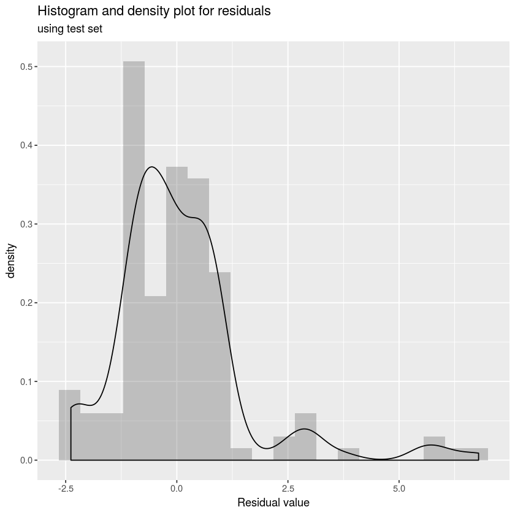

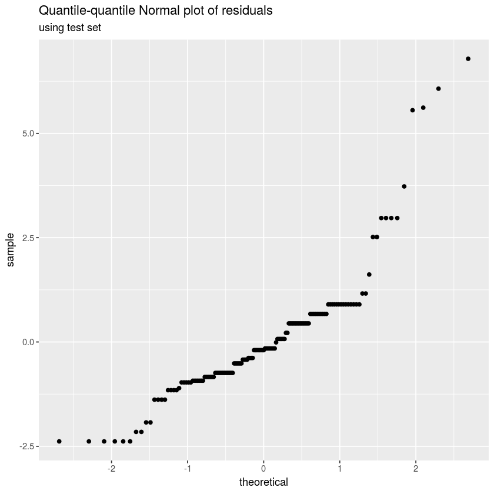

**(Intercept)**

2.15967745866805

**Num_children**

0.2499021682002

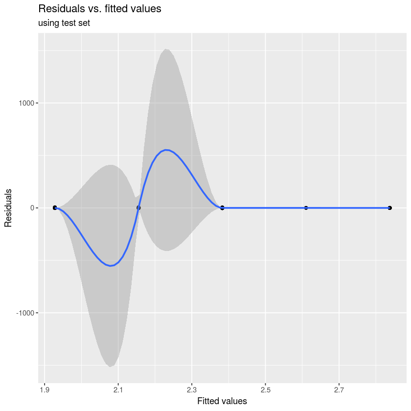

```r
#predict function
predict_score <- function(mod, data){
  data %>%
    mutate(score = predict(mod, newdata=data),
           resids=Absenteeism_hours.sqr - score,
           predicted.Absenteeism = (score*score))
}

#plot residuals function
resids_plot <- function(data){
  hd <- data %>% ggplot(aes(resids, ..density..))+
    geom_histogram(bins=20, alpha=0.3)+
    geom_density()+
    labs(title="Histogram and density plot for residuals", x="Residual value", subtitle="using test set")
  qq <- data %>% ggplot(aes(sample=resids))+
    geom_qq()+
    labs(title="Quantile-quantile Normal plot of residuals", subtitle="using test set")
  scat <- data %>% ggplot(aes(score, resids))+
    geom_point()+
    geom_smooth(method="loess")+
    labs(title="Residuals vs. fitted values", x="Fitted values", y="Residuals", subtitle="using test set")
  hd %>% print()
  qq %>% print()
  scat %>% print()
}

#model 1 performance
df_test_predict1 <- predict_score(model_1, df_test)
df_test_predict1 %>% select(Absenteeism_hours, score, resids, predicted.Absenteeism) %>% return()

df_test_predict1 %>% resids_plot()

model_1$coef

#model 2 performance
df_test_predict2 <- predict_score(model_2, df_test)
df_test_predict2 %>% select(Absenteeism_hours, score, resids, predicted.Absenteeism) %>% return()

df_test_predict2 %>% resids_plot()

model_2$coef
```

# Analysis and Conclusions

Just doing a basic visual analysis to determine potential features with Absenteeism_hours, it appears that there are trends with Education, BMI, Commute_distance, Age, Hit_target, Num_children, Num_pets, Transportation_expense, Service_time, Social_drinker, and Social_smoker.

Chart 1 does a slightly deeper dive and compares Age and BMI_status to Absenteeism_hours. The data indicates that as someone of a normal BMI_status ages, they are likely to miss more work. Conversely, those that are overweight or obese, tend to miss less work as they age.

The second group of charts shows the relationship that Day_of_week and Seasons has on Absenteeism_hours. Mondays have the highest total absenteesim while Thursdays have the lowest. Companies should get prepared to have the most absences on Mondays, and maybe arrange more team work on Thursday. Winter has the highest absenteesim hours, at almost 1500 hours. Autumn has the lowest around 1150.

Chart 3 is interesting in that those with high school(1) and postgraduate(3) educations appear to miss the least amount of work at a time, but those with an undergraduate degree(2) have the highest mean and appear to miss the most amount of work at a time. However, those with a high school education have more single instances of missing work.

Our visual charts led us to perform t-tests with Education since the results seemed so weird. The results of these tests indicated that there is not a significant difference between those with undergrad and graduate degrees. Alternatively, the average absenteeism hours of people with high school degrees is higher than people with graduate degrees.

Model 2 shows that Absenteeism_hours.sqr is modeled by Num_Children. The R-squared value is also very low, however the Num_children is slightly more significant than the features in Model 1. The residuals plot and quantile quantile plot also share the same behavior in Model 1. The residuals compared to fitted values has a lot of variation at the lower end, suggesting that our first model might be slightly better. Regardless, this model is still considered statistically significant.

In summary, the factors that negatively impact absenteeism at work are "normal" BMI status around age 37 and higher, the day of the week being Monday and season being Winter, having an undergraduate degree, a shorter commute distance, a higher transportation expense, and having more children.